# Drivetrain torque split and lateral tyre capacity

A friction-circle analysis of AWD, FWD and RWD on low-friction surfaces

08 August 2026

> Generated by Claude Opus 5

# 1 Scope

This note isolates the effect of longitudinal torque distribution on vehicle behaviour at the friction limit. Tyre compound, surface friction, electronic stability control, speed, radius, mass and driver input are held fixed.

The motivating scenario is a right-hand curve at roughly $0^\circ$C in which the right front tyre encounters a patch of ice.

**Mass is not independent of drivetrain.** A second motor adds roughly 60–100 kg that cannot be declined, and it shifts the centre of gravity. What follows is a partial derivative with a known confound, not a clean experiment.

# 2 Symbol glossary

## 2.1 Indices

| Symbol | Meaning | Type |
| --- | --- | --- |
| $i$ | tyre index, $i \in \{\mathrm{fl}, \mathrm{fr}, \mathrm{rl}, \mathrm{rr}\}$ | index (front/rear $\times$ left/right) |
| $x, y, z$ | axis labels in the tyre’s contact-patch frame: $x$ longitudinal (forward), $y$ lateral, $z$ vertical | subscript labels, not variables |

## 2.2 Contact forces

$F_x$, $F_y$ and $F_z$ are **not functions**. They are the three scalar Cartesian components of the contact force vector $\mathbf{F}_i = (F_{x,i},\, F_{y,i},\, F_{z,i})$ at tyre $i$. Where the tyre index is dropped, read $i = \mathrm{fr}$ — the right front, the wheel on the ice.

| Symbol | Meaning | Units | Sign convention |
| --- | --- | --- | --- |
| $F_{x,i}$ | longitudinal force at tyre $i$ | N | $> 0$ tractive, $< 0$ braking or regen |
| $F_{y,i}$ | lateral (cornering) force at tyre $i$ | N | $> 0$ toward turn centre |
| $F_{z,i}$ | vertical load carried by tyre $i$ | N | always $\ge 0$ |
| $F_x^{\text{tot}}$ | total longitudinal force at the vehicle, summed over four tyres | N | as above |

## 2.3 Surface and capacity

[output not shown]

## 2.4 Demand, split and loss

[output not shown]

## 2.5 Vehicle and control

| Symbol | Meaning | Units |
| --- | --- | --- |
| $m$ | vehicle mass | kg |
| $g$ | gravitational acceleration, $9.81$ | m/s$^2$ |
| $v$ | forward speed | m/s |
| $R_c$ | curve radius | m |
| $a_y$ | lateral acceleration, $a_y = v^2 / R_c$ | m/s$^2$ |
| $h$ | centre-of-gravity height | m |
| $t$ | track width | m |
| $\alpha_r$ | rear-axle slip angle | rad |
| $\tau$ | drivetrain torque-reallocation latency | s |
| $\tau_r$ | rotor time constant of an induction machine, $\tau_r = L_r / R_r$ | s |
| $\hat{\mu}$ | controller’s running estimate of surface friction | dimensionless |

# 3 The friction-circle relations

## 3.1 Friction circle (the constraint)

Longitudinal and lateral force compete for one budget:

$$\sqrt{F_{x,i}^2 + F_{y,i}^2} \;\le\; C_i
\;=\; \mu_i F_{z,i}$$

## 3.2 Normalised demand (the definition)

$$\lambda \;\equiv\;
\frac{F_x^{\text{tot}}}{2\,C_{\mathrm{fr}}}
\qquad\Longrightarrow\qquad
F_{x,\mathrm{fr}} \;=\; \varphi\,\frac{F_x^{\text{tot}}}{2}
\;=\; \varphi\lambda\,C_{\mathrm{fr}}$$

So $\lambda = 1$ means an FWD car’s front tyres would be exactly saturated by longitudinal force alone, leaving zero cornering force.

## 3.3 Retained lateral capacity (the result)

$$F_{y,\mathrm{fr}}^{\max}(\varphi,
\lambda)
\;=\; C_{\mathrm{fr}}\sqrt{1 - (\varphi\lambda)^2},
\qquad \varphi\lambda \le 1$$

and $0$ for $\varphi\lambda > 1$: the tyre is saturated, sliding, and contributing no cornering force at all.

## 3.4 The gain function

The relative improvement of a given split over FWD, everything else fixed:

$$G(\varphi, \lambda)
\;=\; \frac{F_{y}^{\max}(\varphi, \lambda)}{F_{y}^{\max}(1, \lambda)} -
1
\;=\; \sqrt{\frac{1 - (\varphi\lambda)^2}{1 - \lambda^2}} -
1$$

# 4 The loss function and optimal allocation

## 4.1 Convexity

Define the capacity foregone at a tyre:

$$\ell(\lambda) \;=\; 1 - \sqrt{1 -
\min(\lambda, 1)^2}$$

$\ell$ is increasing and **convex** on $[0, 1]$, with a hard wall at $\lambda = 1$. Its small-argument expansion is

$$\ell(\lambda) \;=\;
\tfrac{1}{2}\lambda^2 + \tfrac{1}{8}\lambda^4 +
O(\lambda^6)$$

## 4.2 Jensen: why equal splitting is optimal under uncertainty

For a fixed total demand $D$ allocated across axles, convexity of $\ell$ gives

$$2\,\ell\!\left(\tfrac{D}{2}\right)
\;\le\; \ell(D) + \ell(0) \;=\; \ell(D)$$

so summed loss is minimised by equalising demand. This is the formal content of the intuition that a symmetric split is robust when the location of the compromised tyre is unknown: **convexity of the loss is a sufficient condition for equal splitting to be optimal under uncertainty.**

The refinement matters. $\lambda_i$ is normalised by the *local* budget $C_i = \mu_i F_{z,i}$, and those budgets differ across tyres because of load transfer. Equalising $\lambda_i$ therefore means allocating force **proportional to $\mu_i F_{z,i}$**, not equally. A 50:50 split is optimal only under the prior that all four budgets are equal — it is the maximum-entropy default, not the true optimum. Load-proportional allocation is the target a well-designed controller should pursue.

# 5 Implementation

```r
lateral_capacity <- function(phi, lambda) {
  saturation <- pmin(phi * lambda, 1)
  sqrt(1 - saturation^2)
}

capacity_loss <- function(lambda) {
  1 - lateral_capacity(phi = 1, lambda = lambda)
}

gain_over_fwd <- function(phi, lambda) {
  fwd_capacity <- lateral_capacity(phi = 1, lambda = lambda)
  if_else(
    fwd_capacity > 0,
    lateral_capacity(phi, lambda) / fwd_capacity - 1,
    NA_real_
  )
}

expected_loss <- function(phi, lambda, oversteer_penalty) {
  capacity_loss(phi * lambda) +
    oversteer_penalty * capacity_loss((1 - phi) * lambda)
}

optimal_front_share <- function(lambda,
                                oversteer_penalty,
                                grid = seq(0, 1, by = 0.0005)) {
  losses <- expected_loss(grid, lambda, oversteer_penalty)
  grid[which.min(losses)]
}

optimal_front_share_small_lambda <- function(oversteer_penalty) {
  oversteer_penalty / (1 + oversteer_penalty)
}

split_colours <- c(
  "#e34948", "#eb6834", "#eda100", "#1baf7a", "#2a78d6"
)

theme_note <- function() {
  theme_minimal(base_size = 11) +
    theme(
      panel.grid.minor = element_blank(),
      legend.title = element_text(size = 10),
      legend.key.width = unit(1.6, "lines")
    )
}
```

# 6 Figure 1: the friction circle

Both panels show the same tyre with the same budget $C$; only the longitudinal demand differs.

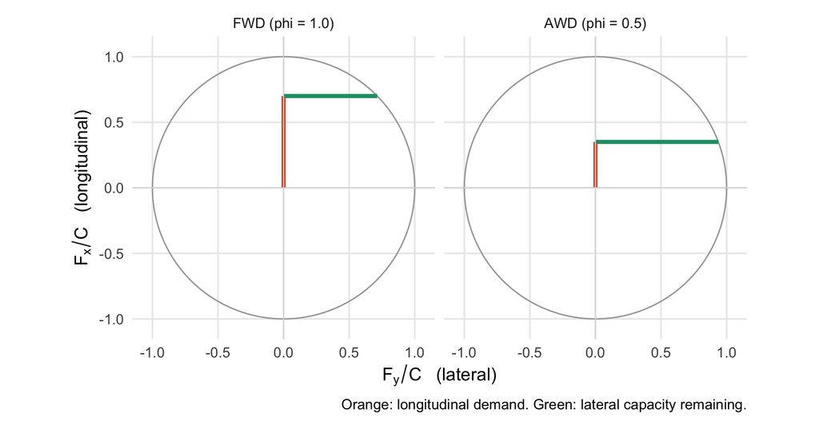

```r
circle_path <- tibble(
  theta = seq(0, 2 * pi, length.out = 361),
  fy = cos(theta),
  fx = sin(theta)
)

operating_vectors <- tibble(
  split = factor(
    c("FWD (phi = 1.0)", "AWD (phi = 0.5)"),
    levels = c("FWD (phi = 1.0)", "AWD (phi = 0.5)")
  ),
  fx = c(0.70, 0.35)
) |>
  mutate(fy = sqrt(1 - fx^2))

ggplot() +
  geom_path(
    data = circle_path,
    aes(x = fy, y = fx),
    colour = "grey65",
    linewidth = 0.4
  ) +
  geom_segment(
    data = operating_vectors,
    aes(x = 0, y = 0, xend = 0, yend = fx),
    colour = "#d85a30",
    linewidth = 1.2
  ) +
  geom_segment(
    data = operating_vectors,
    aes(x = 0, y = fx, xend = fy, yend = fx),
    colour = "#1d9e75",
    linewidth = 1.2
  ) +
  geom_hline(yintercept = 0, colour = "grey85", linewidth = 0.3) +
  geom_vline(xintercept = 0, colour = "grey85", linewidth = 0.3) +
  facet_wrap(vars(split)) +
  coord_fixed(xlim = c(-1.05, 1.05), ylim = c(-1.05, 1.05)) +
  labs(
    x = expression(F[y] / C ~ "  (lateral)"),
    y = expression(F[x] / C ~ "  (longitudinal)"),
    caption = paste(
      "Orange: longitudinal demand.",
      "Green: lateral capacity remaining."
    )
  ) +
  theme_note()
```

Halving the front axle’s longitudinal duty takes the tyre from roughly 71% to 94% of its lateral limit. AWD does not add grip; it stops the front axle from spending grip on propulsion.

# 7 Figure 2: retained capacity across the demand range

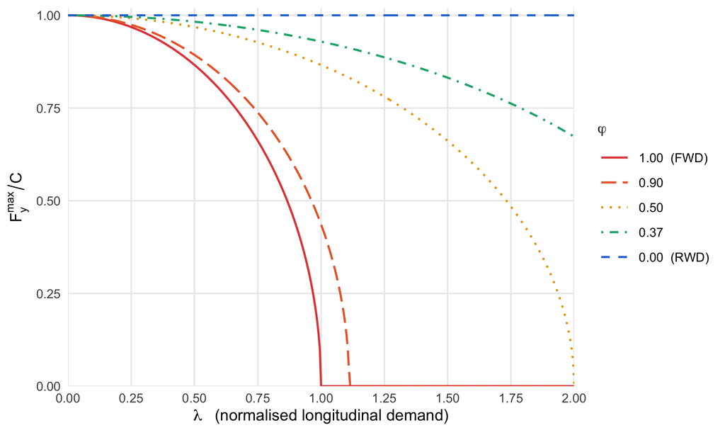

```r
phi_levels <- c(1, 0.9, 0.5, 0.37, 0)

phi_labels <- c("1.00  (FWD)", "0.90", "0.50", "0.37", "0.00  (RWD)")

capacity_grid <- expand_grid(
  phi = phi_levels,
  lambda = seq(0, 2, by = 0.005)
) |>
  mutate(
    capacity = lateral_capacity(phi, lambda),
    phi_label = factor(phi, levels = phi_levels, labels = phi_labels)
  )

ggplot(
  capacity_grid,
  aes(x = lambda, y = capacity, colour = phi_label, linetype = phi_label)
) +
  geom_line(linewidth = 0.7) +
  scale_colour_manual(values = set_names(split_colours, phi_labels)) +
  scale_linetype_manual(
    values = c("solid", "longdash", "dotted", "dotdash", "dashed")
  ) +
  scale_x_continuous(breaks = seq(0, 2, by = 0.25), expand = c(0, 0)) +
  scale_y_continuous(limits = c(0, 1.02), expand = c(0, 0)) +
  labs(
    x = expression(lambda ~ "  (normalised longitudinal demand)"),
    y = expression(F[y]^max / C),
    colour = expression(varphi),
    linetype = expression(varphi)
  ) +
  theme_note()
```

Each curve is a quarter-ellipse in disguise: $\varphi$ rescales the $\lambda$ axis, so the FWD curve reaches zero at $\lambda = 1$ while the $\varphi = 0.5$ curve survives to $\lambda = 2$. The $\varphi = 0$ line is flat at 1 — a tyre asked to do no longitudinal work retains its full budget for cornering regardless of what the rest of the car is doing.

# 8 Figure 3: the gain function

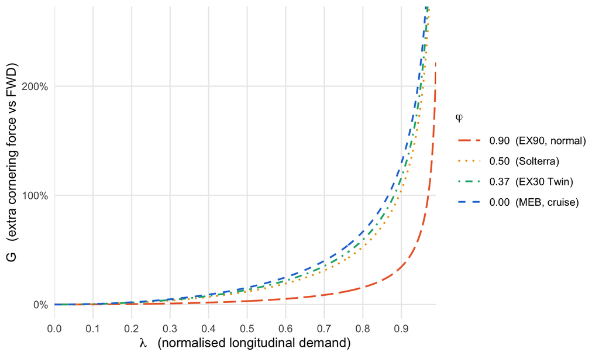

```r
gain_levels <- c(0.9, 0.5, 0.37, 0)

gain_labels <- c(
  "0.90  (EX90, normal)",
  "0.50  (Solterra)",
  "0.37  (EX30 Twin)",
  "0.00  (MEB, cruise)"
)

gain_grid <- expand_grid(
  phi = gain_levels,
  lambda = seq(0, 0.99, by = 0.002)
) |>
  mutate(
    gain = gain_over_fwd(phi, lambda),
    phi_label = factor(phi, levels = gain_levels, labels = gain_labels)
  )

ggplot(
  gain_grid,
  aes(x = lambda, y = gain, colour = phi_label, linetype = phi_label)
) +
  geom_line(linewidth = 0.7) +
  scale_colour_manual(values = set_names(split_colours[-1], gain_labels)) +
  scale_linetype_manual(values = c("longdash", "dotted", "dotdash", "dashed")) +
  scale_x_continuous(breaks = seq(0, 1, by = 0.1), expand = c(0, 0)) +
  scale_y_continuous(labels = scales::percent_format(accuracy = 1)) +
  coord_cartesian(ylim = c(0, 2.6)) +
  labs(
    x = expression(lambda ~ "  (normalised longitudinal demand)"),
    y = "G   (extra cornering force vs FWD)",
    colour = expression(varphi),
    linetype = expression(varphi)
  ) +
  theme_note()
```

# 9 Three mechanisms, not one

Sections 3–4 evaluate the objective at the front axle only. That is blind to the asymmetry in *consequences*:

- **Front saturation $\rightarrow$ understeer.** Yaw rate falls below commanded, the car runs wide, $R_c$ increases, $a_y = v^2 / R_c$ drops, and the front tyres recover. Self-limiting: the plant returns toward the limit unaided, and the corrective input is intuitive.
- **Rear saturation $\rightarrow$ oversteer.** Yaw rate exceeds commanded, which increases $\alpha_r$, which reduces rear lateral force, which increases yaw rate further. Positive feedback, divergent, requiring an active and counterintuitive correction inside a short window.

So there are three distinct mechanisms, and they do not share a sign:

|  | Mechanism | Favours |
| --- | --- | --- |
| **(A)** | Friction-budget competition at the steering axle | rear drive |
| **(B)** | Asymmetric loss: understeer recoverable, oversteer divergent | front drive |
| **(C)** | Point of application of the tractive force relative to the CoG | front drive |

Mechanism (C) is separate from (B) and holds independently of whether any tyre is saturated. A tractive force applied *ahead* of the CoG rotates with the steered wheels and generates a moment opposing any yaw perturbation. Applied *behind* the CoG it stays aligned with the body and, once the body yaws, acquires a lateral component that amplifies the yaw. This is why RWD vehicles spin under power and FWD vehicles essentially do not.

Two of the three favour the front. The Section 3–4 conclusion that rear bias is preferable holds *conditional on the ice being under a front wheel*. As a general prior it does not survive.

# 10 Optimising the split

## 10.1 The objective

$$\mathbb{E}[L](\varphi) \;=\;
w_A\,\ell(\varphi\lambda)
\;+\; w_B\,\ell\big((1-\varphi)\lambda\big),
\qquad k \equiv \frac{w_B}{w_A} \ge 1$$

Opposing gradients with convex terms give a convex sum, hence an **interior** minimum.

## 10.2 Closed form in the small-$\lambda$ limit

Substituting $\ell(x) \approx x^2/2$:

$$\mathbb{E}[L](\varphi) \;\approx\;
\frac{\lambda^2}{2}
\left[\varphi^2 + k\,(1-\varphi)^2\right]$$

$$\frac{\partial}{\partial \varphi}: \quad
2\varphi - 2k(1-\varphi) = 0
\quad\Longrightarrow\quad
\boxed{\;\varphi^* = \frac{k}{1+k}\;}
\quad\Longleftrightarrow\quad
\frac{\varphi^*}{1-\varphi^*} = k$$

**The optimal front:rear torque ratio equals the rear:front loss ratio**, and in this limit it is independent of $\lambda$. With no oversteer penalty ($k = 1$) it returns $\varphi^* = 0.5$, recovering the Jensen result. As $k \to \infty$ it tends to pure FWD. Saturation effects at high $\lambda$ pull $\varphi^*$ below the closed form, as Figure 6 shows.

## 10.3 Figure 4: convexity and the Jensen construction

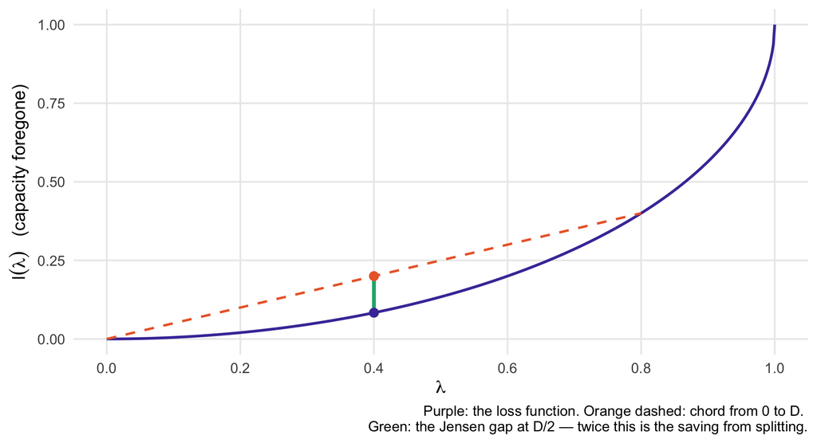

```r
demand_total <- 0.8

loss_curve <- tibble(lambda = seq(0, 1, by = 0.002)) |>
  mutate(loss = capacity_loss(lambda))

chord <- tibble(
  lambda = c(0, demand_total),
  loss = capacity_loss(c(0, demand_total))
)

jensen_gap <- tibble(
  lambda = demand_total / 2,
  curve_value = capacity_loss(demand_total / 2),
  chord_value = capacity_loss(demand_total) / 2
)

ggplot() +
  geom_line(
    data = loss_curve,
    aes(x = lambda, y = loss),
    colour = "#4a3aa7",
    linewidth = 0.8
  ) +
  geom_line(
    data = chord,
    aes(x = lambda, y = loss),
    colour = "#eb6834",
    linetype = "dashed",
    linewidth = 0.7
  ) +
  geom_segment(
    data = jensen_gap,
    aes(x = lambda, xend = lambda, y = curve_value, yend = chord_value),
    colour = "#1baf7a",
    linewidth = 1.1
  ) +
  geom_point(
    data = jensen_gap,
    aes(x = lambda, y = curve_value),
    colour = "#4a3aa7",
    size = 2.2
  ) +
  geom_point(
    data = jensen_gap,
    aes(x = lambda, y = chord_value),
    colour = "#eb6834",
    size = 2.2
  ) +
  scale_x_continuous(breaks = seq(0, 1, by = 0.2)) +
  labs(
    x = expression(lambda),
    y = expression(l(lambda) ~ "  (capacity foregone)"),
    caption = paste(
      "Purple: the loss function. Orange dashed: chord from 0 to D.",
      "\nGreen: the Jensen gap at D/2 — twice this is the saving from",
      "splitting."
    )
  ) +
  theme_note()
```

```r
tibble(
  allocation = c("Concentrated (FWD)", "Symmetric (50:50)"),
  front_demand = c(demand_total, demand_total / 2),
  rear_demand = c(0, demand_total / 2)
) |>
  mutate(
    summed_loss = capacity_loss(front_demand) + capacity_loss(rear_demand)
  ) |>
  mutate(across(where(is.numeric), \(x) round(x, 4))) |>
  knitr::kable(
    caption = paste0(
      "Summed loss at equal total demand D = ", demand_total,
      ". Convexity guarantees the split is never worse."
    )
  )
```

Summed loss at equal total demand D = 0.8. Convexity guarantees the split is never worse.

| allocation | front_demand | rear_demand | summed_loss |
| --- | --- | --- | --- |
| Concentrated (FWD) | 0.8 | 0.0 | 0.400 |
| Symmetric (50:50) | 0.4 | 0.4 | 0.167 |

## 10.4 Figure 5: expected loss against the front share

Weights are **stipulated, not measured**. Treat the shape as the result, not the location of the argmin.

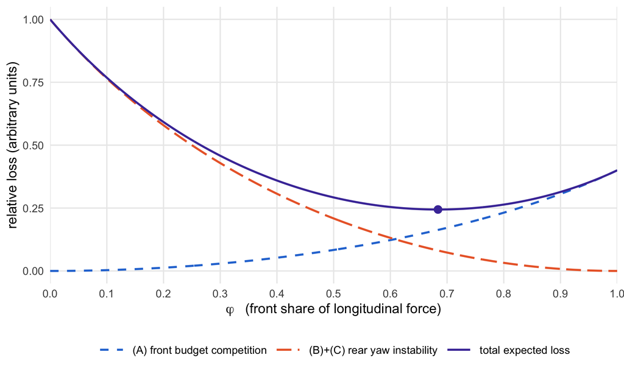

```r
reference_lambda <- 0.8
reference_penalty <- 2.5

loss_decomposition <- tibble(phi = seq(0, 1, by = 0.002)) |>
  mutate(
    front_budget = capacity_loss(phi * reference_lambda),
    rear_instability = reference_penalty *
      capacity_loss((1 - phi) * reference_lambda),
    total = front_budget + rear_instability
  ) |>
  pivot_longer(
    cols = c(front_budget, rear_instability, total),
    names_to = "component",
    values_to = "loss"
  ) |>
  mutate(
    component = factor(
      component,
      levels = c("front_budget", "rear_instability", "total"),
      labels = c(
        "(A) front budget competition",
        "(B)+(C) rear yaw instability",
        "total expected loss"
      )
    )
  )

phi_star <- optimal_front_share(reference_lambda, reference_penalty)

minimum_point <- tibble(
  phi = phi_star,
  loss = expected_loss(phi_star, reference_lambda, reference_penalty)
)

ggplot(loss_decomposition, aes(x = phi, y = loss)) +
  geom_line(aes(colour = component, linetype = component), linewidth = 0.8) +
  geom_point(data = minimum_point, colour = "#4a3aa7", size = 2.6) +
  scale_colour_manual(values = c("#2a78d6", "#eb6834", "#4a3aa7")) +
  scale_linetype_manual(values = c("dashed", "longdash", "solid")) +
  scale_x_continuous(breaks = seq(0, 1, by = 0.1), expand = c(0, 0)) +
  labs(
    x = expression(varphi ~ "  (front share of longitudinal force)"),
    y = "relative loss (arbitrary units)",
    colour = NULL,
    linetype = NULL
  ) +
  theme_note() +
  theme(legend.position = "bottom")
```

At $\lambda = 0.8$ and $k = 2.5$ the grid search gives $\varphi^* = 0.684$, against a closed-form prediction of $0.714$. The optimum is interior and **front-biased**.

## 10.5 Figure 6: sensitivity of $\varphi^*$ to the oversteer penalty

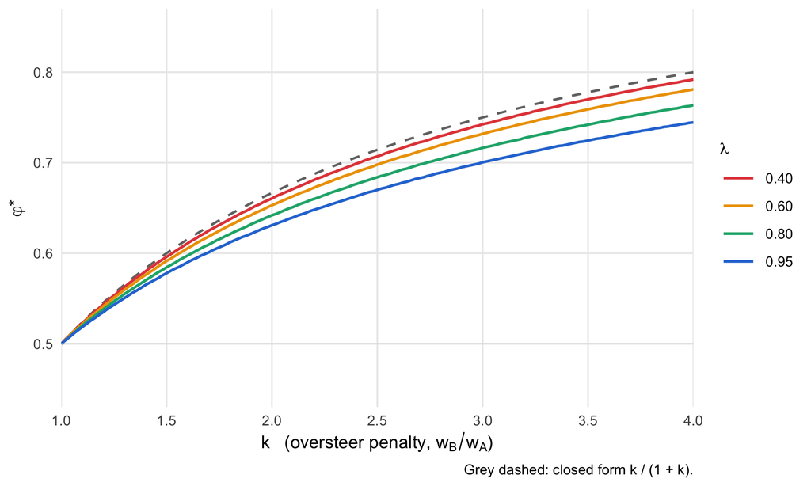

```r
penalty_grid <- expand_grid(
  lambda = c(0.4, 0.6, 0.8, 0.95),
  oversteer_penalty = seq(1, 4, by = 0.02)
) |>
  mutate(
    phi_star = map2_dbl(lambda, oversteer_penalty, optimal_front_share),
    lambda_label = factor(
      lambda,
      levels = c(0.4, 0.6, 0.8, 0.95),
      labels = c("0.40", "0.60", "0.80", "0.95")
    )
  )

closed_form <- tibble(oversteer_penalty = seq(1, 4, by = 0.02)) |>
  mutate(phi_star = optimal_front_share_small_lambda(oversteer_penalty))

ggplot(penalty_grid, aes(x = oversteer_penalty, y = phi_star)) +
  geom_line(
    data = closed_form,
    colour = "grey45",
    linetype = "dashed",
    linewidth = 0.7
  ) +
  geom_line(aes(colour = lambda_label), linewidth = 0.8) +
  geom_hline(yintercept = 0.5, colour = "grey80", linewidth = 0.3) +
  scale_colour_manual(values = split_colours[c(1, 3, 4, 5)]) +
  scale_x_continuous(breaks = seq(1, 4, by = 0.5), expand = c(0, 0)) +
  scale_y_continuous(limits = c(0.45, 0.85)) +
  labs(
    x = expression(k ~ "  (oversteer penalty, " * w[B] / w[A] * ")"),
    y = expression(varphi * "*"),
    colour = expression(lambda),
    caption = "Grey dashed: closed form k / (1 + k)."
  ) +
  theme_note()
```

The closed form is a good approximation at low $\lambda$ and an upper bound throughout: as the front saturation wall at $\varphi\lambda = 1$ approaches, $\varphi^*$ is pulled down.

This has an external validation. Mass-market Haldex-based AWD systems default to roughly 90:10 or 95:5 front. Audi’s Torsen quattro ran 40:60 rear-biased — and was sold on handling, not safety. The safety-optimised industry answer has consistently been front-biased AWD, which is what this decomposition predicts.

It also reframes Subaru. A 50:50 manual centre diff, or 45:55 in the VTD automatics, sits *rear* of the safety optimum. That is a traction-and-balance calibration consistent with the rally lineage, not a stability-maximising one.

# 11 Locating the operating points

**Lateral load transfer** (quasi-static, ignoring roll-stiffness distribution between axles):

$$\Delta F_z = \frac{m\,a_y\,h}{t},
\qquad
F_{z,\mathrm{fr}} = \frac{mg}{4} - \frac{\Delta F_z}{2}$$

**Regeneration demand:** $\;F_x^{\text{tot}} = -\eta\,m g$

```r
g_const <- 9.81

vehicle <- list(
  mass_kg = 2000,
  cog_height_m = 0.62,
  track_width_m = 1.58,
  mu_ice = 0.10,
  lateral_accel_g = 0.30
)

lateral_load_transfer_n <-
  vehicle$mass_kg * vehicle$lateral_accel_g * g_const *
    vehicle$cog_height_m / vehicle$track_width_m

static_corner_load_n <- vehicle$mass_kg * g_const / 4

inside_front_load_n <- static_corner_load_n - lateral_load_transfer_n / 2

friction_budget_n <- vehicle$mu_ice * inside_front_load_n

tibble(
  quantity = c(
    "Lateral load transfer (N)",
    "Static corner load (N)",
    "Inside front load F_z,fr (N)",
    "Friction budget C_fr (N)"
  ),
  value = round(
    c(
      lateral_load_transfer_n,
      static_corner_load_n,
      inside_front_load_n,
      friction_budget_n
    ),
    1
  )
) |>
  knitr::kable(caption = "Derived quantities for the reference vehicle.")
```

Derived quantities for the reference vehicle.

| quantity | value |
| --- | --- |
| Lateral load transfer (N) | 2309.7 |
| Static corner load (N) | 4905.0 |
| Inside front load F_z,fr (N) | 3750.2 |
| Friction budget C_fr (N) | 375.0 |

```r
operating_points <- tibble(
  condition = c(
    "Coasting, regen off",
    "Steady 80 km/h",
    "Lift-off regen, eta = 0.05",
    "Lift-off regen, eta = 0.15"
  ),
  fx_total_n = c(
    0,
    450,
    0.05 * vehicle$mass_kg * g_const,
    0.15 * vehicle$mass_kg * g_const
  )
) |>
  mutate(
    lambda = fx_total_n / (2 * friction_budget_n),
    fwd = lateral_capacity(phi = 1, lambda = lambda),
    awd_symmetric = lateral_capacity(phi = 0.5, lambda = lambda)
  )

operating_points |>
  mutate(across(c(fx_total_n, lambda, fwd, awd_symmetric), \(x) round(x, 2))) |>
  knitr::kable(
    col.names = c(
      "Condition", "F_x total (N)", "lambda",
      "F_y/C at phi = 1", "F_y/C at phi = 0.5"
    ),
    caption = "Operating points on the low-friction patch."
  )
```

Operating points on the low-friction patch.

| Condition | F_x total (N) | lambda | F_y/C at phi = 1 | F_y/C at phi = 0.5 |
| --- | --- | --- | --- | --- |
| Coasting, regen off | 0 | 0.00 | 1.0 | 1.00 |
| Steady 80 km/h | 450 | 0.60 | 0.8 | 0.95 |
| Lift-off regen, eta = 0.05 | 981 | 1.31 | 0.0 | 0.76 |
| Lift-off regen, eta = 0.15 | 2943 | 3.92 | 0.0 | 0.00 |

The friction budget of that tyre is roughly 375 N — about the weight of a large dog. Steady cruise already consumes a substantial fraction of it, and any meaningful regeneration saturates it outright. At the highest $\lambda$ in the table, halving $\varphi$ still leaves $\varphi\lambda > 1$: neither drivetrain saves you, only reducing $F_x^{\text{tot}}$ does.

# 12 Latency and the endogeneity of $\varphi$

Treating $\varphi$ as a constant understates a dual-motor AWD system. In a two-eAxle EV, $\varphi$ is a control output spanning the full $[0, 1]$ range, switchable in roughly 10–20 ms. In principle such a system can *be* the RWD car when that is optimal and the FWD car when it is not.

The binding constraint is **observability**. Available signals are wheel speeds (a lagging indicator — slip must already have occurred), motor currents, IMU yaw and acceleration, steering angle, and a recursively estimated $\hat\mu$. There is no forward-looking friction sensor: the vehicle cannot see the ice patch. So $\varphi$ is held at a prior until slip is detected, then corrected. The default-$\varphi$ analysis therefore remains the correct analysis for the first 50–100 ms, which is frequently the window in which the outcome is settled.

The consequence is that the operative advantage of a symmetric dual-PMSM system is not its default $\varphi = 0.5$ but that **$\tau$ is small and symmetric in direction**.

| Architecture | Shed front torque | Add front torque | Notes |
| --- | --- | --- | --- |
| Dual PMSM, both live | ~10–20 ms | ~10–20 ms | inverter-limited, direction-symmetric |
| Rear PMSM + de-excited front ASM | immediate (already ~0) | $O(\tau_r)$, tens of ms | asymmetric; slow to add front |
| Front-primary + rear clutch | immediate | n/a | slow to *shed*: clutch engagement plus speed synchronisation |
| Brake-based left–right (all of the above) | 100–200 ms | 100–200 ms | ESC pump pressure build, plus detection latency |

Under a prior of “I do not know which tyre will slip, or in which direction I will need to move torque,” a maximum-entropy default plus minimum direction-symmetric latency is the coherent design.